# Prediction of Diabetes

## 0. Objective:

In this project we are going to develop a model to predict if a person is diabetic or not, based on attributes of Pima-Indians diabetes data from UCI repository. Since, our target is a binary decision (Yes or No), we are going to use supervised classification algorithms. Based on online studies and papers, we are targeting to achieve 75+ % or above model classification accuracy (https://www.ijedr.org/papers/IJEDR1703069.pdf) with minimum false negative (High Recall) of the model.

Minimum False Negative: So that we should not miss any patient with a diabetic. For this classification we can tolerate some false positive(Patients misclassified as diabetic). If we mis-classify a non-diabetic person as a diabetic then he/she will go for further testing where they will get to know that they are non-diabetic.

## INDEX

- 1. LOAD THE LIBRARIES AND READ THE DATA
  - 1.1. LOAD LIBRARIES
  - 1.2. READ THE DATA
- 2. OVERVIEW
  - 2.1. DATA INFORMATION
  - 2.2. HEAD
  - 2.3. TARGET
  - 2.4. DATA DISTRIBUTION
- 3. REPLACE MISSING VALUES WITH MEDIAN
  - 3.1. CORRELATION WITH TARGET VARIABLE
- 4. RESEARCHING FOR A BEST MODEL FOR THE GIVEN DATASET
- 5. MODEL OPTIMIZATION AND PERFORMANCE EVALUATION
- 6. FEATURE ADDITION
- 7. CONCLUSION
  - 7.1. SCOPE FOR FURTHER INVESTIGATION

## 1. LOAD LIBRARIES AND READ THE DATA

### 1.1. LOAD LIBRARIES

```python
#Import initial libraries
import numpy as np
import pandas as pd

# Libraries for plotting
import seaborn as sns
#from pandas.tools.plotting import scatter_matrix
import matplotlib.pyplot as plt
plt.style.use('fivethirtyeight')

%matplotlib inline
import plotly.offline as py
import plotly.graph_objs as go
from plotly.offline import download_plotlyjs, init_notebook_mode, plot, iplot
import plotly.tools as tls
import plotly.figure_factory as ff

# Import time
import time

#ignore warning messages
import warnings
warnings.filterwarnings('ignore')
style_dict = {'background-color':'lightyellow','color':'#000000','border-color': 'red','font-family':'Roboto'}
```

### 1.2. READ THE DATA

Data source: [Pima Indians Diabetes](https://archive.ics.uci.edu/ml/datasets/Pima+Indians+Diabetes)

```python
# Load the data in the python environment
original_data = pd.read_csv("diabetes.csv",sep = ",")
```

```python
# Shape of the data:
print("Our dataset has {} rows and {} columns.".format(original_data.shape[0], original_data.shape[1]))
```

```
Our dataset has 768 rows and 9 columns.
```

## 2. OVERVIEW

### 2.1. DATA INFORMATION

```python
# Data columns in the dataset:
original_data.columns
```

```
Index(['Pregnancies', 'Glucose', 'BloodPressure', 'SkinThickness', 'Insulin',
       'BMI', 'DiabetesPedigreeFunction', 'Age', 'Outcome'],
      dtype='object')
```

**Attribute Information:**

1. Pregnancies : Number of times pregnant -
2. Glucose : Plasma glucose concentration a 2 hours in an oral glucose tolerance test
3. Blood Pressure: Diastolic blood pressure (mm Hg)
4. SkinThickness : Triceps skin fold thickness (mm)
5. Insulin : 2-Hour serum insulin (mu U/ml)
6. BMI : Body mass index (weight in kg/(height in m)^2)
7. DiabetesPedigreeFunction : Diabetes pedigree function
8. Age : Age

**Target** 9. data.columns(0 or 1) - "class_variable" 1 is yes and 0 is no.*

### 2.2. HEAD

```python
# First three rows of the dataset:
original_data.head(10).style.set_properties(**style_dict)
```

|  | Pregnancies | Glucose | BloodPressure | SkinThickness | Insulin | BMI | DiabetesPedigreeFunction | Age | Outcome |
| --- | --- | --- | --- | --- | --- | --- | --- | --- | --- |
| 0 | 6 | 148 | 72 | 35 | 0 | 33.6 | 0.627 | 50 | 1 |
| 1 | 1 | 85 | 66 | 29 | 0 | 26.6 | 0.351 | 31 | 0 |
| 2 | 8 | 183 | 64 | 0 | 0 | 23.3 | 0.672 | 32 | 1 |
| 3 | 1 | 89 | 66 | 23 | 94 | 28.1 | 0.167 | 21 | 0 |
| 4 | 0 | 137 | 40 | 35 | 168 | 43.1 | 2.288 | 33 | 1 |
| 5 | 5 | 116 | 74 | 0 | 0 | 25.6 | 0.201 | 30 | 0 |
| 6 | 3 | 78 | 50 | 32 | 88 | 31 | 0.248 | 26 | 1 |
| 7 | 10 | 115 | 0 | 0 | 0 | 35.3 | 0.134 | 29 | 0 |
| 8 | 2 | 197 | 70 | 45 | 543 | 30.5 | 0.158 | 53 | 1 |
| 9 | 8 | 125 | 96 | 0 | 0 | 0 | 0.232 | 54 | 1 |

### 2.3. TARGET

```python
# Check for data balance:
# Check the balance of the dataset :
info = go.Pie(labels = ['Healthy','Diabetic'], values = original_data['Outcome'].value_counts(),
                   textfont=dict(size=15), opacity = 0.8,
                   marker=dict(colors=['lightyellow', 'lightgreen'],
                               line=dict(color='#000000', width=1.5)))
layout = dict(title =  'Distribution of Outcome variable')
fig = dict(data = [info], layout=layout)
py.iplot(fig)
```

[interactive chart not shown]

### 2.4. DATA DISTRIBUTION

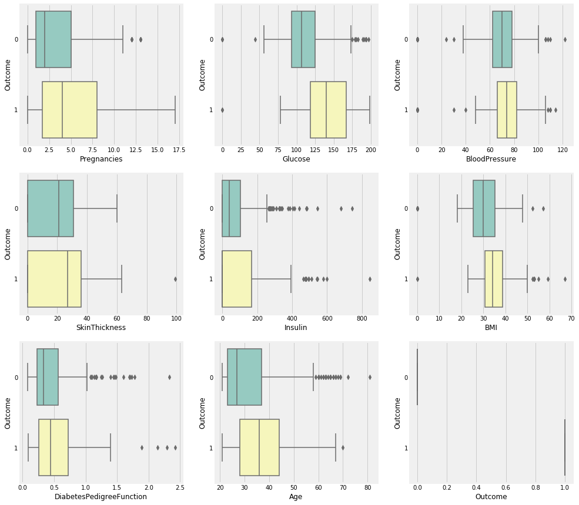

```python
fig, axs = plt.subplots(3,3, figsize=(15, 15))
for i,name in enumerate(original_data.columns):
    plt.subplot(3, 3, i+1)
    sns.boxplot(x= name, y=original_data.Outcome, data=original_data,palette="Set3",orient='h',linewidth=1.5)
plt.show()
```

**Observations:**

- Median of healthy class and diabetic class within a feature is different in most of the cases. Ex: In first Boxplot, a median of no. of pregnancies and diabetic patients is more than the median of pregnancies and healthy patients.

  **We will use this information at the time of replacing nan or zeros in the dataset.**

## 3. REPLACING MISSING VALUES WITH MEDIAN

**Steps:**

1. Replace zeros with NaN.
2. Replace NaNs with class-median of respective columns.

```python
# Replace zeros with NaN and later we will change NaNs with class-median of respective columns.
original_data[['Glucose', 'BloodPressure','SkinThickness', 'Insulin', 'BMI']] = original_data[['Glucose', 'BloodPressure',
       'SkinThickness', 'Insulin', 'BMI']].replace(0,np.NaN)
```

```python
# Define missing plot to detect all missing values in dataset
def missing_plot(dataset, key,title) :
    null_feat = pd.DataFrame(len(dataset[key]) - dataset.isnull().sum(), columns = ['Count'])
    percentage_null = pd.DataFrame((len(dataset[key]) - (len(dataset[key]) - dataset.isnull().sum()))/len(dataset[key])*100, columns = ['Count'])
    percentage_null = percentage_null.round(2)
    trace = go.Bar(x = null_feat.index, y = null_feat['Count'],opacity = 0.8, text = percentage_null['Count'],  textposition = 'auto',marker=dict(color = 'lightyellow',
    line=dict(color='lightgreen',width=1.5)))
    layout = dict(title =  title+": Missing Values (count & %)" )
    fig = dict(data = [trace], layout=layout)
    py.iplot(fig)

#Repalce NaN values with median:
def replacing_missing_values(dataset,key):
    for var in dataset[dataset.columns[:-1]].columns:
        temp = dataset[dataset[var].notnull()]
        temp = temp[[var, key]].groupby([key])[[var]].median().reset_index()
        dataset.loc[(dataset[key] == 0 ) & (dataset[var].isnull()), var] = temp.values[0][1]
        dataset.loc[(dataset[key] == 1 ) & (dataset[var].isnull()), var] = temp.values[1][1]
    return dataset.head(10)

# Draw a plot before and after
def fill_missing_values(dataset,key,t1 ="Before",t2 = "After"):
    missing_plot(dataset,key,t1)
    plt.show()
    datset= replacing_missing_values(dataset, key)
    missing_plot(dataset,key,t2)
    plt.show()
```

```python
fill_missing_values(original_data,'Outcome')
```

[interactive chart not shown]

**Above, the first graph shows the percentage of missing values and the second graph shows missing values filled with class-median.**

### 3.1. CORRELATION WITH TARGET VARIABLE

**This how features fro the dataset are correlated with the target variable.**

```python
#Check the correlation
original_data.corr()['Outcome'].sort_values()
```

```
DiabetesPedigreeFunction    0.173844
BloodPressure               0.174469
Pregnancies                 0.221898
Age                         0.238356
SkinThickness               0.295138
BMI                         0.315577
Insulin                     0.377081
Glucose                     0.495990
Outcome                     1.000000
Name: Outcome, dtype: float64
```

## 4. RESEARCHING FOR A BEST MODEL FOR THE GIVEN DATASET

### 4.1. SPLIT THE DATA INTO FEATURES AND TARGET

```python
#Split the data in features and target
X = original_data.iloc[:,:-1]
y = original_data.iloc[:,-1]
```

I have created a classification function - all_in_one, which divides the dataset into three subsets namely,

```
 1. Training dataset ~ 60%
 2. Cross Validation dataset ~ 20%
 3. Testing dataset ~20%
```

Also, in this function I have used following classification algorithms to do initial algorithm performance comparison by getting learning curves, classification report and ROC curves.

[1. Logistic Regression Classifier](https://scikit-learn.org/stable/modules/generated/sklearn.linear_model.LogisticRegression.html)  
[2. Decision Tree Classifier](https://scikit-learn.org/stable/modules/generated/sklearn.tree.DecisionTreeClassifier.html)  
[3. Random Forest Classifier](https://scikit-learn.org/stable/modules/generated/sklearn.ensemble.RandomForestClassifier.html)  
[4. Support Vector Machine Classifier](https://scikit-learn.org/stable/modules/generated/sklearn.svm.SVC.html)  
[5. Gaussian NB Classifier](https://scikit-learn.org/stable/modules/generated/sklearn.naive_bayes.GaussianNB.html)  
[6. K -nearest neighbors Classifier](https://scikit-learn.org/stable/modules/neighbors.html)  
[7. Gradient Boosting Classifier](https://scikit-learn.org/stable/modules/generated/sklearn.ensemble.GradientBoostingClassifier.html)  
[8. Extreme Gradient Boosting classifier](https://scikit-learn.org/stable/modules/generated/sklearn.ensemble.GradientBoostingClassifier.html)

### 4.2. LET'S GET THE BASIC UNDERSTANDING OF THE DATASET AND PROBLEM

```
Training Dataset : (460, 8) (460,)
Testing Dataset: (154, 8) (154,)
Validation Dataset: (154, 8) (154,)
```

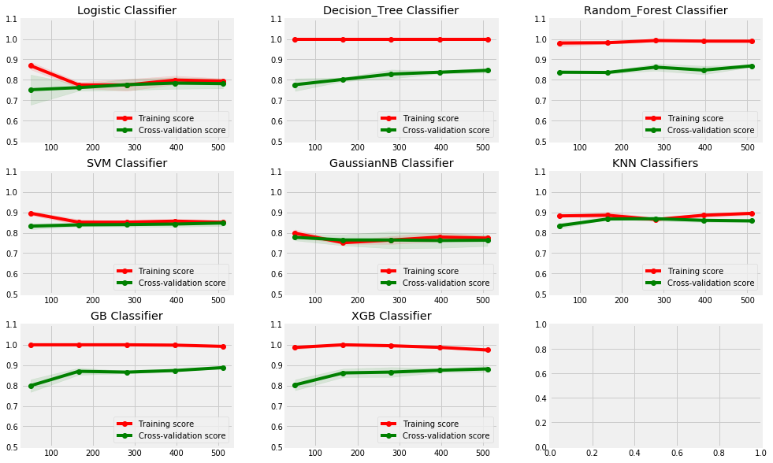

```
                      Model  Accuracy  Precision    Recall       F1   \
1       Logistic Classifier  0.759740   0.605263  0.867925  0.713178
2  Decision_Tree Classifier  0.831169   0.745455  0.773585  0.759259
3  Random_Forest Classifier  0.837662   0.741379  0.811321  0.774775
4            SVM Classifier  0.792208   0.652174  0.849057  0.737705
5     GaussianNB Classifier  0.733766   0.611111  0.622642  0.616822
6           KNN Classifiers  0.824675   0.724138  0.792453  0.756757
7             GB Classifier  0.850649   0.741935  0.867925  0.800000
8            XGB Classifier  0.844156   0.730159  0.867925  0.793103

        ROC      Time
1  0.785447  0.002769
2  0.817486  0.002069
3  0.831403  0.008615
4  0.805716  0.011272
5  0.707360  0.001418
6  0.817018  0.005226
7  0.854754  0.053940
8  0.849804  0.022572

==========================================================================
```

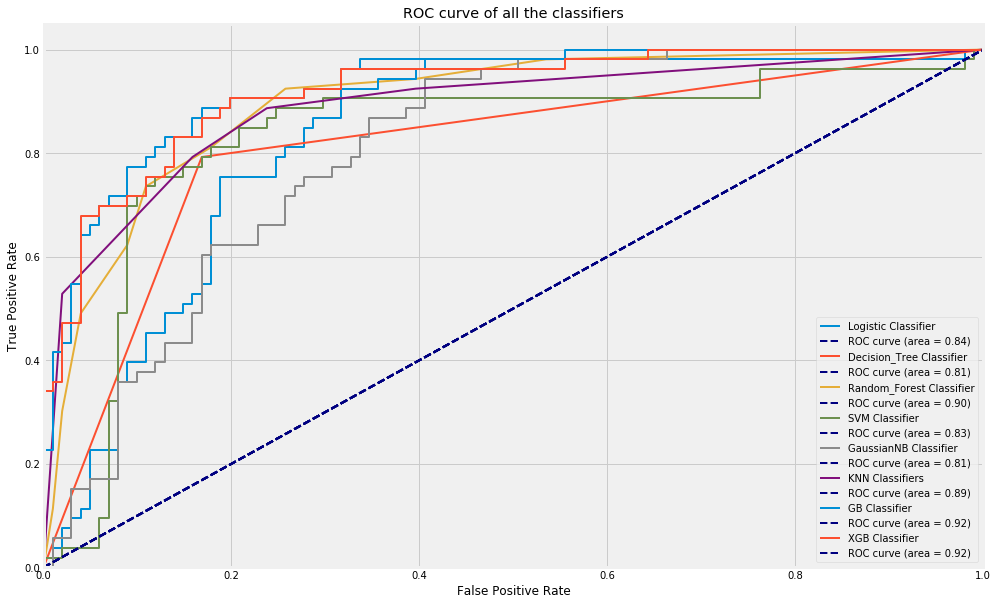

```python
# Import classifiers into the notebook:
import classifiers

classifiers.all_in_one(X,y)
```

#### Observations :

1) Logistic regression:(Under-fitting) Estimator shows ~75% accuracy on training dataset and shows same accuracy on the Cross-Validation dataset with no improvement by increasing the dataset. It clearly shows high bias(Under-fitting) of the estimator. Adding more dataset is not going to help here. We need to explore the complexity of the model.

2) Decision Tree:(Over-fitting) Estimator perfectly trained on the training dataset but doesn't have the same accuracy on the Cross-Validation dataset with little improvement with increasing dataset. The gap between training curve and CV curve is considerable, which means(Over-fitting) the estimator fits well on training set but fail to predict on testing dataset. We need to explore the optimization option here also need to work on data gathering.

3) Random Forest:(Over-fitting)The issue is exactly similar to Decision Tree,need to see parameter optimization options.

7) Gradient Boosting Classifier:(High Variance) This looks like the estimator has a variance issue. It clearly shows that if we increase the dataset we can get better accuracy. Also need to explore parameter optimization.

8) Extreme Gradient Boosting Classifier:(High Variance) As Gradient boost ,this also looks like the estimator has a variance issue. It clearly shows that if we increase the dataset we can get better accuracy. Also need to explore parameter optimization.

## 5. MODEL OPTIMIZATION AND PERFORMANCE EVALUATION

Based on our first exploration, we are to going to focus on optimization of:

1. Random Forest Model
2. Gradient Boosting Model
3. Extreme Boosting Model

**Note:** Just to know parameter optimization of other classification algorithms we are going to do it for all the above mentioned classification algorithms. But, we will mainly focusing on the performance of Random Forest, Gradient Boosting and Extreme Gradient Boosting algorithms.

```python
from classifiers import Optimization
Optimization(X,y)
```

```
Fitting 5 folds for each of 10 candidates, totalling 50 fits
```

[output not shown]

```
Logistic Regression :
{'penalty': 'l2', 'class_weight': 'balanced', 'C': 2}
Fitting 5 folds for each of 10 candidates, totalling 50 fits
Decision Tree :
{'min_samples_split': 3, 'min_samples_leaf': 18, 'max_depth': 4, 'criterion': 'entropy'}
Fitting 5 folds for each of 10 candidates, totalling 50 fits
```

[output not shown]

```
Random Forest :
{'n_estimators': 300, 'min_samples_split': 8, 'min_samples_leaf': 14, 'max_depth': 3, 'criterion': 'gini'}
Fitting 5 folds for each of 4 candidates, totalling 20 fits
Support Vector Machine :
{'gamma': 'scale', 'C': 0.001}
Fitting 5 folds for each of 10 candidates, totalling 50 fits
```

[output not shown]

```
K-Nearest Neighbor :
{'n_neighbors': 20, 'leaf_size': 5, 'algorithm': 'ball_tree'}
Fitting 5 folds for each of 10 candidates, totalling 50 fits
```

```
[Parallel(n_jobs=-1)]: Done  50 out of  50 | elapsed:    0.8s finished
[Parallel(n_jobs=-1)]: Using backend LokyBackend with 12 concurrent workers.
```

```
Gradient Boosting :
{'n_estimators': 200, 'max_depth': 2, 'loss': 'exponential', 'learning_rate': 0.03}
Fitting 5 folds for each of 10 candidates, totalling 50 fits
Extreme Gradient Boosting :
{'scale_pos_weight': 5, 'n_estimators': 250, 'max_depth': 2, 'learning_rate': 0.03}
                       Model  Accuracy  Precision    Recall       F1   \
1        Logistic Regression  0.802083   0.670732  0.833333  0.743243
2              Decision Tree  0.807292   0.698630  0.772727  0.733813
3              Random Forest  0.843750   0.725000  0.878788  0.794521
4     Support Vector Machine  0.656250   0.000000  0.000000  0.000000
5         K-Nearest Neighbor  0.828125   0.739130  0.772727  0.755556
6          Gradient Boosting  0.848958   0.803279  0.742424  0.771654
7  Extreme Gradient Boosting  0.833333   0.693182  0.924242  0.792208

        ROC
1  0.809524
2  0.799062
3  0.852092
4  0.500000
5  0.814935
6  0.823593
7  0.854978
==============================================================================
```

```
[Parallel(n_jobs=-1)]: Done  50 out of  50 | elapsed:    0.5s finished
```

### Based on the above exploration we are going to explore optimization for Gradient Boosting and Extreme Gradient Boosting algorithms.

## 6. ADDITIONAL EXPLORATION

```python
from sklearn.model_selection import KFold
from sklearn.metrics import roc_auc_score , precision_score, recall_score, f1_score, classification_report,accuracy_score,confusion_matrix,roc_curve, auc
from sklearn.model_selection import RandomizedSearchCV
from sklearn.metrics import balanced_accuracy_score
from xgboost import XGBClassifier
from sklearn.ensemble import GradientBoostingClassifier
```

```python
from sklearn.model_selection import train_test_split


Best_parameters = pd.DataFrame([[0,0]],columns=['Model','Best_Parameters'])
results = pd.DataFrame([[0, 0,0,0, 0,0 ]],columns = ['Model', 'Accuracy', 'Precision', 'Recall', 'F1 ','ROC' ])
for i in range(10):
    X_train, X_test, y_train, y_test = train_test_split(X,y, test_size=0.25)

    # Create a list of classifiers
    classifiers = {'Gradient Boosting':GradientBoostingClassifier(),
                'Exteme Gradient Boosting':XGBClassifier()}

    kfold = KFold(n_splits = 5, random_state = 123)

    # Parameters grids for that model
    models_and_parameters = {'GB':(GradientBoostingClassifier(),{'loss': ['deviance', 'exponential'],
                            'learning_rate': [.03, .1, .3, 1, 3],'n_estimators':[150,200,300],'max_depth':[2,3,4,5]}),

                            'XGB':(XGBClassifier(),{'learning_rate': [.03, .1, .3, 1, 3],
                                              'n_estimators':[50,70,100,150,200,250],'max_depth':[2,3,4,5],'scale_pos_weight' :[1,1.5,2,2.5,3,4,5,6]})

                            }

    for name, (model, params) in models_and_parameters.items():
        clf = RandomizedSearchCV(estimator = model, param_distributions = params, cv = kfold, n_jobs = -1, verbose = 2, scoring="balanced_accuracy").fit(X_train,y_train)
        #print(name,":")
        #print(clf.best_params_)
        y_pred = clf.predict(X_test)
        roc = roc_auc_score(y_test, y_pred)
        acc = accuracy_score(y_test, y_pred)
        prec = precision_score(y_test, y_pred)
        rec = recall_score(y_test, y_pred)
        f1  = f1_score(y_test, y_pred)
        Bestparameters = pd.DataFrame([[name, clf.best_params_]],columns=['Model','Best_Parameters'])
        Best_parameters = Best_parameters.append(Bestparameters, ignore_index = True)
        model_results =  pd.DataFrame([[name, acc,prec,rec, f1,roc]],columns = ['Model', 'Accuracy', 'Precision', 'Recall', 'F1 ','ROC'])
        results = results.append(model_results, ignore_index = True)
print("==============================================================================")
print("Gradient Boosting Classifier")
#print((results.iloc[1::2]))
print(results.iloc[1::2].describe())
print("==============================================================================")

print("Extreme Gradient Boosting Classifier" )
#print((results.iloc[2::2]))
print(results.iloc[2::2].describe())
```

[output not shown]

[output not shown]

[output not shown]

[output not shown]

[output not shown]

[output not shown]

[output not shown]

[output not shown]

[output not shown]

[output not shown]

[output not shown]

[output not shown]

[output not shown]

[output not shown]

[output not shown]

[output not shown]

[output not shown]

[output not shown]

[output not shown]

[output not shown]

[output not shown]

[output not shown]

[output not shown]

[output not shown]

[output not shown]

[output not shown]

[output not shown]

[output not shown]

[output not shown]

[output not shown]

[output not shown]

[output not shown]

[output not shown]

[output not shown]

[output not shown]

[output not shown]

[output not shown]

[output not shown]

[output not shown]

```
Fitting 5 folds for each of 10 candidates, totalling 50 fits
==============================================================================
Gradient Boosting Classifier
        Accuracy  Precision     Recall        F1         ROC
count  10.000000  10.000000  10.000000  10.000000  10.000000
mean    0.870313   0.817358   0.799301   0.804956   0.854244
std     0.020898   0.064945   0.062487   0.032960   0.026824
min     0.843750   0.738462   0.706667   0.769231   0.822168
25%     0.854167   0.759701   0.759963   0.775461   0.832389
50%     0.864583   0.821372   0.798465   0.792348   0.848598
75%     0.890625   0.837366   0.837928   0.839579   0.872143
max     0.901042   0.933333   0.888889   0.850394   0.896821
==============================================================================
Extreme Gradient Boosting Classifier
        Accuracy  Precision     Recall        F1         ROC
count  10.000000  10.000000  10.000000  10.000000  10.000000
mean    0.871354   0.780269   0.872833   0.819650   0.873017
std     0.020841   0.075083   0.064506   0.031008   0.022815
min     0.828125   0.694444   0.780822   0.751880   0.825867
25%     0.864583   0.727553   0.821421   0.804861   0.862301
50%     0.869792   0.745373   0.891813   0.823878   0.871348
75%     0.885417   0.833858   0.929654   0.838488   0.885890
max     0.901042   0.919355   0.950820   0.863309   0.902958
```

```
[Parallel(n_jobs=-1)]: Done  50 out of  50 | elapsed:    0.4s finished
```

**NOTE:**

Also, we tried adding squared and cubed values of the features in the dataset, but it isn't adding any information in the model prediction.

## 7. CONCLUSION

In this study, we investigate various classification algorithms to get best prediction accuracy with minimum false negative instances of diabetes. We explored various data-preprocessing techniques to find the best results. After all the activities we performed, we came to know that Extreme Gradient Boosting Classifier and Gradient Boosting classifier are the best performing algorithms on this dataset. So we would recommend to use these model for predicting diabetes.

### 7.1. SCOPE FOR FURTHER INVESTIGATION

As we have not used all the available machine learning classification algorithms and related techniques, there are strong possibilities to get better results. I would also recommend to explore deep learning to see if we can get better results.